# Introducción a la regresión lineal simple (II)

Ejercicio integrador

Germán Rosati

10 agosto, 2026

## Introducción

En el dataset ‘./data/wb_bank_data_2019.csv’ tienen información construida por el Banco Mundial acerca de la distribución de la población ocupada según grandes sectores de actividad y categoría ocupacional:

- `SL.AGR.EMPL.ZS.2019`: % total de empleo en agricultura: actividades de agricultura, silvicultura, caza y pesca
- `SL.IND.EMPL.ZS.2019`: % total de empleo en industria: actividades de minas y canteras, manufacturas, construcción y energía, gas y agua.
- `SL.SERV.EMPL.ZS.2019`: % total de empleo en servicios: comprende comercio al por mayor y menor y restaurantes y hoteles, transporte, almacenamiento y comunicaciones, finanzas, seguros, servicios inmobiliarios y a las empresas y servicios personales, sociales y comunales.
- `SL.FAM.WORK.ZS.2019`: % total de trabajadores familiares
- `SL.EMP.MPYR.ZS.2019`: % total de empleadores
- `SL.EMP.SELF.ZS.2019`: % total de independientes (cuenta propia)
- `SL.EMP.WORK.ZS.2019`: % total de trabajadores asalariados

## 1. Carguen los paquetes a utilizar

```r
> library(tidyverse)
```

## 2. Carguen el dataset

```r
> df <- read_csv('./data/wb_bank_data_2019.csv')
>
>
> head(df)
```

```
## # A tibble: 6 × 7
##   iso3c  date value indicatorID       indicator                    iso2c country
##   <chr> <dbl> <dbl> <chr>             <chr>                        <chr> <chr>
## 1 AFG    2019  42.8 SL.AGR.EMPL.ZS    Employment in agriculture (… AF    Afghan…
## 2 AFG    2019  18.2 SL.IND.EMPL.ZS    Employment in industry (% o… AF    Afghan…
## 3 AFG    2019  39.0 SL.SRV.EMPL.ZS    Employment in services (% o… AF    Afghan…
## 4 AFG    2019  43.5 SL.EMP.TOTL.SP.ZS Employment to population ra… AF    Afghan…
## 5 ALB    2019  36.7 SL.AGR.EMPL.ZS    Employment in agriculture (… AL    Albania
## 6 ALB    2019  20.0 SL.IND.EMPL.ZS    Employment in industry (% o… AL    Albania
```

## 3. ¿Qué formato tiene el dataset?

Apilado o “Long”.

**Importante:** observar el formato de la tabla e indicar qué transformación (o transformaciones) sería necesaria para poder trabajarla de forma correcta.

```r
> df <- df %>%
+   pivot_wider(id_cols = c(iso3c, iso2c, country),
+               names_from = c(indicatorID, date),
+               names_sep = ".",
+               values_from = value)
```

## 4. ¿Existe una correlación entre ambas variables? ¿Cómo lo podrían evaluar? Describa la relación

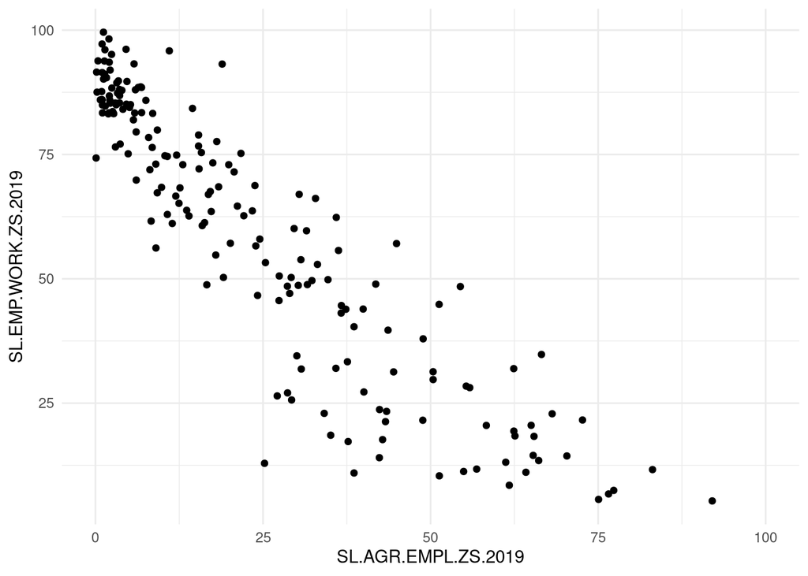

```r
> df %>%
+   ggplot(aes(x=SL.AGR.EMPL.ZS.2019, y=SL.EMP.WORK.ZS.2019)) +
+     geom_point() +
+     xlim(0,100) +
+     theme_minimal()
```

## 5. Si consideran que tiene sentido, corran una regresión entre ambas variables

```r
> lm <- lm(SL.EMP.WORK.ZS.2019 ~ SL.AGR.EMPL.ZS.2019, data=df)
>
```

## 6. Impriman una tabla resumen de la regresión

```r
> summary(lm)
```

```
##
## Call:
## lm(formula = SL.EMP.WORK.ZS.2019 ~ SL.AGR.EMPL.ZS.2019, data = df)
##
## Residuals:
##     Min      1Q  Median      3Q     Max
## -45.217  -5.620   1.575   6.802  27.923
##
## Coefficients:
##                     Estimate Std. Error t value Pr(>|t|)
## (Intercept)         86.56534    1.23605   70.03   <2e-16 ***
## SL.AGR.EMPL.ZS.2019 -1.12767    0.03817  -29.55   <2e-16 ***
## ---
## Signif. codes:  0 '***' 0.001 '**' 0.01 '*' 0.05 '.' 0.1 ' ' 1
##
## Residual standard error: 11.4 on 185 degrees of freedom
## Multiple R-squared:  0.8251, Adjusted R-squared:  0.8242
## F-statistic:   873 on 1 and 185 DF,  p-value: < 2.2e-16
```

## 7. Interpreten los coeficientes

```r
> coef(lm)
```

```
##         (Intercept) SL.AGR.EMPL.ZS.2019
##           86.565344           -1.127669
```

## 8. ¿Qué ajuste tiene la regresión? ¿Qué proporción de la variabilidad de la variable dependiente es capturada por el modelo?

```r
> ###
```

## 9. Generen e interpreten un residual plot (gráfico de residuos)

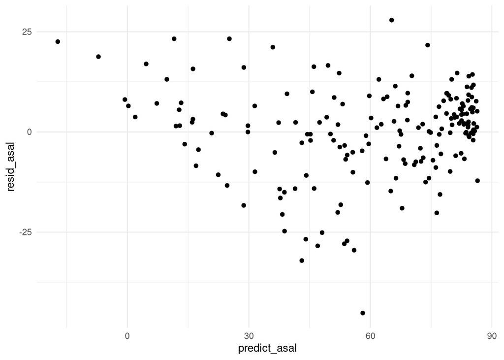

```r
> resid_plot <- tibble(
+   resid_asal = residuals(lm),
+   predict_asal = predict(lm, df),
+   asal_orig = df$SL.EMP.WORK.ZS.2019)
>
> resid_plot %>%
+   ggplot(aes(x=predict_asal, y=resid_asal)) +
+     geom_point() +
+     theme_minimal()
```